# Análisis descriptivo e Inferencia

Alba Fuster y Javir Martín-Pozuelo

# Análisis descriptivo

La base de datos consta de 18 observaciones y 4 variables. Estas variables son:

- colony: Indica la colonia a la que pertenece la medición (observación).
- visitors: Representa el número de visitantes que se emplearon para calcular la distancia de vuelo.
- density: Representa la densidad de la colonia de animales.
- meanFID: Indica la distancia de vuelo promedio.

En el análisis estadístico no se empleará la variable `colony` ya que esta variable es únicamente un indicador (coincide con las observaciones). Además, la variable respuesta será `meanFID`, ya que se tiene interés en explicar esta distancia de vuelo en función del resto de covariables.

## Variable implicadas en el estudio

En la Figura 1, se observa el histograma de la variable respuesta FID, donde vemos que es una variable cuantitativa, continua y positiva. Por otro lado, para la covariable número de visitantes y densidad se observar que ambas tienen un outlier y que el rango de valores es muy amplio, sobretodo en el número de visitantes, por tanto, podría plantearse la transformación de las mismas con funciones como el logaritmo o la raíz.

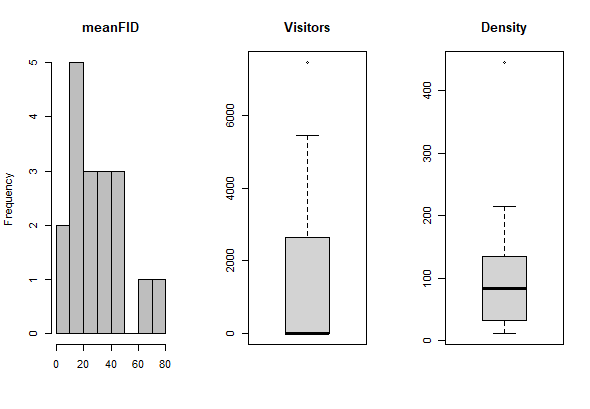

## Relación de las variables implicadas en el estudio

En la Figura 2 se aprecia la curva de densidad para cada una de las variables. Si nos fijamos en la curva para la FID es posible ver que tiene una forma asimétrica, desplazada a la derecha, en consecuencia, se planteará como función de distribución para la variable una gamma. En lo referente a las variables explicativas se grafica el suavizado con la variable respuesta para ver si existe una relación aparente entre ellas. Del mismo modo, destaca la correlación de *Pearson* entre la variable FID y el número de visitantes, con un valor negativo de -0.531.

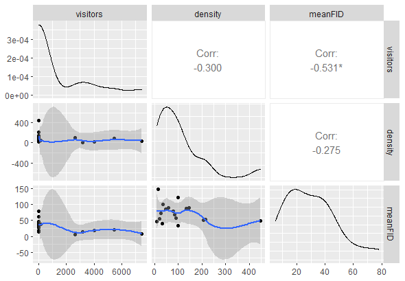

# Modelización

A continuación, se presentarán los resultados obtenidos para el mejor modelo (M4.C y M4.B) con las dos perspectivas: clásica y bayesiana. El código de este y el resto de modelos se puede encontrar en el script adjunto en el repositorio.

$$\text{Y}_{i} \sim \text{Gamma}(\mu_{i}, \phi) \quad i = 1...18,$$
$$log(\mu_{i}) = \beta_{0} + \beta_{1}\text{X}_{i} + \beta_{2}\text{X}_{i}^2 + \beta_{3}\text{X}_{i}^3 + \beta_{4}\sqrt{\text{Z}_{i}},$$
donde, $\text{Y}_{i}$ representa la variable respuesta FID, $\text{X}_{i}$ la covariable número de visitantes, $\text{Z}_{i}$ la covariable densidad y $\mu_{i}$ la media de la distribución, la cual se enlaza a un predictor lineal mediante la función de enlace logaritmo. Del mismo modo, los parámetros a estimar son $\beta_{0},\beta_{1},\beta_{2},\beta_{3},\beta_{4}$ y el hiperparámetro $\phi$.

# Inferencia

En general, es posible realizar inferencia estadística desde dos perspectivas distintas: la **frecuentista** y la **bayesiana**. La principal diferencia entre ambas es como interpretan la probabilidad:

- La aproximación frecuentista se centra en la probabilidad de los datos dado un parámetro $\beta$, $\text{P}(\text{datos}|\beta)$. En consecuencia, se obtiene una estimación puntual de $\beta$ con un intervalo de confianza al 95 %.
- La aproximación bayesiana se centra en la probabilidad del parámetro $\beta$ dado los datos $\text{P}(\beta|\text{datos})$. De forma que, se obtiene una distribución del parámetro que aporta toda la información posible sobre $\beta$. Haciendo uso del teorema de Bayes (1), es posible obtener dicha distribución a posteriori:

$$\text{P}(\beta|\text{datos}) \propto \text{P}(\text{datos}|\beta) × \text{P}(\beta), \quad (1)$$
donde, $\text{P}(\beta|\text{datos})$ corresponde con la distribución a posteriori, $\text{P}(\text{datos}|\beta)$ es la verosimilitud de los datos y $\text{P}(\beta)$ es la distribución a priori, en el caso de tener información previa sobre el parámetro a estimar.

## Resultados: Inferencia clásica

En los resultados de la inferencia clásica simplemente tenemos una estimación puntual de cada uno de los parámetros con un p-valor asociado, en el caso de que ese p-valor sea significativa, es decir, menor de 0.05, el coeficiente es distinto de 0. Se pueden obtener también los intervalos de confianza al 95 % para los coeficientes.

```r
M4.C <-
  glm(
    meanFID ~ visitors + I(visitors ^ 2) + I(visitors ^ 3) + sqrt(density),
    family = Gamma(link = "log"),
    data = FID
  )

summary(M4.C)
```

```
##
## Call:
## glm(formula = meanFID ~ visitors + I(visitors^2) + I(visitors^3) +
##     sqrt(density), family = Gamma(link = "log"), data = FID)
##
## Deviance Residuals:
##      Min        1Q    Median        3Q       Max
## -0.56949  -0.13880  -0.02133   0.09848   0.55863
##
## Coefficients:
##                 Estimate Std. Error t value Pr(>|t|)
## (Intercept)    4.492e+00  2.064e-01  21.758 1.31e-11 ***
## visitors      -2.151e-03  3.735e-04  -5.759 6.61e-05 ***
## I(visitors^2)  7.014e-07  1.455e-07   4.819 0.000335 ***
## I(visitors^3) -5.987e-11  1.327e-11  -4.512 0.000584 ***
## sqrt(density) -8.843e-02  1.825e-02  -4.846 0.000319 ***
## ---
## Signif. codes:  0 '***' 0.001 '**' 0.01 '*' 0.05 '.' 0.1 ' ' 1
##
## (Dispersion parameter for Gamma family taken to be 0.09599034)
##
##     Null deviance: 7.3146  on 17  degrees of freedom
## Residual deviance: 1.2576  on 13  degrees of freedom
## AIC: 131.37
##
## Number of Fisher Scoring iterations: 4
```

## Resultados: Inferencia bayesiana

En los resultados de la inferencia bayesiana obtenemos una distribución a posteriori de los parámetros, de esa distribución a posteriori podemos utilizar como estimación puntual, la media, la mediana etc.

```r
M4.B <- inla(
  meanFID ~ visitors + I(visitors ^ 2) + I(visitors ^ 3) + density2,
  data = datos,
  family = "gamma",
  control.compute = list(dic = TRUE, waic = TRUE, cpo = TRUE)
)

summary(M4.B)
```

```
##
## Call:
##    c("inla(formula = meanFID ~ visitors + I(visitors^2) + I(visitors^3) +
##    ", " density2, family = \"gamma\", data = datos, control.compute =
##    list(dic = TRUE, ", " waic = TRUE, cpo = TRUE))")
## Time used:
##     Pre = 0.548, Running = 0.203, Post = 0.449, Total = 1.2
## Fixed effects:
##                 mean    sd 0.025quant 0.5quant 0.975quant   mode kld
## (Intercept)    4.486 0.210      4.071    4.485      4.906  4.483   0
## visitors      -0.002 0.000     -0.003   -0.002     -0.001 -0.002   0
## I(visitors^2)  0.000 0.000      0.000    0.000      0.000  0.000   0
## I(visitors^3)  0.000 0.000      0.000    0.000      0.000  0.000   0
## density2      -0.088 0.018     -0.124   -0.088     -0.051 -0.089   0
##
## Model hyperparameters:
##                                                 mean   sd 0.025quant 0.5quant
## Precision parameter for the Gamma observations 11.97 4.28       5.13    11.45
##                                                0.975quant  mode
## Precision parameter for the Gamma observations      21.75 10.40
##
## Expected number of effective parameters(stdev): 5.00(0.00)
## Number of equivalent replicates : 3.60
##
## Deviance Information Criterion (DIC) ...............: 132.22
## Deviance Information Criterion (DIC, saturated) ....: 27.54
## Effective number of parameters .....................: 6.30
##
## Watanabe-Akaike information criterion (WAIC) ...: 130.85
## Effective number of parameters .................: 4.08
##
## Marginal log-Likelihood:  -135.29
## CPO and PIT are computed
##
## Posterior marginals for the linear predictor and
##  the fitted values are computed
```

La distribuciones a posteriori de los parámetros e hiperparámetros las podemos encontrar en la Figura 3, representando también los intervalos de credibilidad al 95 %.

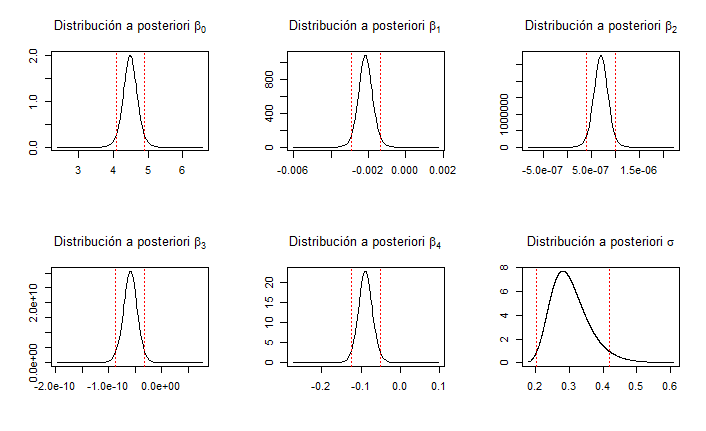